# taitannikehao

## 关于泰坦尼克号生存率的数据分析

首先通过观察数据，可以了解到每位旅客的详细数据：

- **Survived**：是否存活（0代表否，1代表是）
- **Pclass**：舱位（一等舱，二等舱，三等舱）
- **Name**：船上乘客的名字
- **Sex**：船上乘客的性别
- **Age**：船上乘客的年龄（可能存在 NaN）
- **SibSp**：乘客在船上的兄弟姐妹和配偶的数量
- **Parch**：乘客在船上的父母以及小孩的数量
- **Ticket**：乘客船票的编号
- **Fare**：乘客为船票支付的费用
- **Cabin**：乘客所在船舱的编号（可能存在 NaN）
- **Embarked**：乘客上船的港口（C 代表从 Cherbourg 登船，Q 代表从 Queenstown 登船，S 代表从 Southampton 登船）

通过对原始数据的初步观察可以发现存活率和社会等级，性别，年龄，在船上的兄弟姐妹和配偶数量，在船上的父母以及小孩的数量有着某种联系。因此根据初步推测可以提出以下几个问题并进行分析：

- 乘客的存活率和其社会等级是否有关系？是否社会等级越高存活率就越高？
- 乘客的存活率和其性别，年龄又有什么关系？
- 乘客的存活率和其在船上的兄弟姐妹和配偶数量，父母以及小孩的数量又有什么联系？

```python
import numpy as np
import pandas as pd
import matplotlib.pyplot as plt
import pylab as pl
%matplotlib inline
filename = './titanic-data.csv'
titanic_df = pd.read_csv(filename)
titanic_df.describe()
```

|  | PassengerId | Survived | Pclass | Age | SibSp | Parch | Fare |
| --- | --- | --- | --- | --- | --- | --- | --- |
| count | 891.000000 | 891.000000 | 891.000000 | 714.000000 | 891.000000 | 891.000000 | 891.000000 |
| mean | 446.000000 | 0.383838 | 2.308642 | 29.699118 | 0.523008 | 0.381594 | 32.204208 |
| std | 257.353842 | 0.486592 | 0.836071 | 14.526497 | 1.102743 | 0.806057 | 49.693429 |
| min | 1.000000 | 0.000000 | 1.000000 | 0.420000 | 0.000000 | 0.000000 | 0.000000 |
| 25% | 223.500000 | 0.000000 | 2.000000 | 20.125000 | 0.000000 | 0.000000 | 7.910400 |
| 50% | 446.000000 | 0.000000 | 3.000000 | 28.000000 | 0.000000 | 0.000000 | 14.454200 |
| 75% | 668.500000 | 1.000000 | 3.000000 | 38.000000 | 1.000000 | 0.000000 | 31.000000 |
| max | 891.000000 | 1.000000 | 3.000000 | 80.000000 | 8.000000 | 6.000000 | 512.329200 |

```python
titanic_df = titanic_df.fillna(method='pad')#用前一个数值填充

titanic_df.describe()
```

|  | PassengerId | Survived | Pclass | Age | SibSp | Parch | Fare |
| --- | --- | --- | --- | --- | --- | --- | --- |
| count | 891.000000 | 891.000000 | 891.000000 | 891.00000 | 891.000000 | 891.000000 | 891.000000 |
| mean | 446.000000 | 0.383838 | 2.308642 | 29.58156 | 0.523008 | 0.381594 | 32.204208 |
| std | 257.353842 | 0.486592 | 0.836071 | 14.55459 | 1.102743 | 0.806057 | 49.693429 |
| min | 1.000000 | 0.000000 | 1.000000 | 0.42000 | 0.000000 | 0.000000 | 0.000000 |
| 25% | 223.500000 | 0.000000 | 2.000000 | 20.00000 | 0.000000 | 0.000000 | 7.910400 |
| 50% | 446.000000 | 0.000000 | 3.000000 | 28.00000 | 0.000000 | 0.000000 | 14.454200 |
| 75% | 668.500000 | 1.000000 | 3.000000 | 38.00000 | 1.000000 | 0.000000 | 31.000000 |
| max | 891.000000 | 1.000000 | 3.000000 | 80.00000 | 8.000000 | 6.000000 | 512.329200 |

- 可以看出年龄这一列数据的总数正常了，为891，接下来可以进一步分析生存率了。

```
Pclass
1    216
2    184
3    491
Name: PassengerId, dtype: int64
```

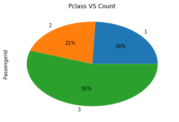

```python
sort_pclass = titanic_df.groupby('Pclass').count()['PassengerId']
print sort_pclass
titanic_df.groupby('Pclass')['PassengerId'].count().plot(kind = 'pie',autopct = '%.0f%%')
plt.title('Pclass VS Count')
plt.show()
```

```
Axes(0.125,0.125;0.775x0.755)
```

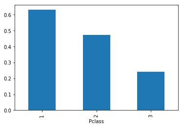

```python
Pclass_survived = titanic_df.groupby('Pclass').mean()['Survived']
print Pclass_survived.plot.bar()
```

```
Sex
female    314
male      577
Name: PassengerId, dtype: int64
Sex
female    0.742038
male      0.188908
Name: Survived, dtype: float64
Axes(0.125,0.125;0.775x0.755)
```

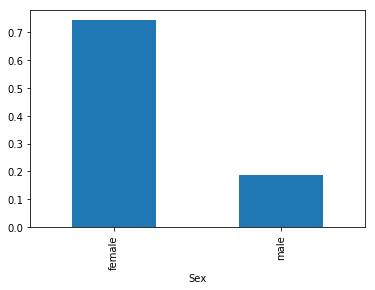

```python
sort_sex = titanic_df.groupby('Sex').count()['PassengerId']
print sort_sex
Sex_survived = titanic_df.groupby('Sex').mean()['Survived']
print Sex_survived
print Sex_survived.plot.bar()
```

- 我们可以清晰的看到虽然船上的男性人数显著多于女性人数，但是女性的存活率高达74%，而男性的存活率只有19%。这说明在逃生的时候会有男性保护女性的情况。一般是女先男后。

```python
titanic_df['Age_bins'] = pd.cut(titanic_df['Age'],range(0,80,10))
Age_survived = titanic_df.groupby('Age_bins').mean()['Survived']
Sort_survived = titanic_df.groupby('Age_bins').count()['Survived']
print Age_survived
print Sort_survived
```

```
Age_bins
(0, 10]     0.564706
(10, 20]    0.361702
(20, 30]    0.334520
(30, 40]    0.424242
(40, 50]    0.357798
(50, 60]    0.358491
(60, 70]    0.315789
Name: Survived, dtype: float64
Age_bins
(0, 10]      85
(10, 20]    141
(20, 30]    281
(30, 40]    198
(40, 50]    109
(50, 60]     53
(60, 70]     19
Name: Survived, dtype: int64
```

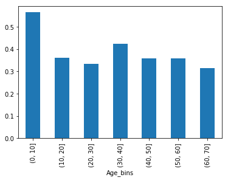

```python
Age_survived.plot(kind='bar', stacked=True)
```

```
SibSp
0    608
1    209
2     28
3     16
4     18
5      5
8      7
Name: PassengerId, dtype: int64
```

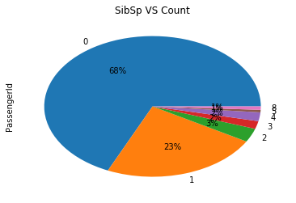

```python
sort_SibSp = titanic_df.groupby('SibSp').count()['PassengerId']
print sort_SibSp
titanic_df.groupby('SibSp')['PassengerId'].count().plot(kind = 'pie',autopct = '%.0f%%')
plt.title('SibSp VS Count')
plt.show()
```

```
SibSp
0    0.345395
1    0.535885
2    0.464286
3    0.250000
4    0.166667
5    0.000000
8    0.000000
Name: Survived, dtype: float64
```

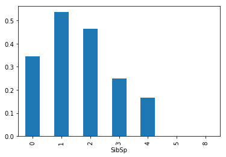

```python
SibSp_survived = titanic_df.groupby('SibSp').mean()['Survived']
print SibSp_survived
SibSp_survived.plot.bar()
```

```
Parch
0    678
1    118
2     80
3      5
4      4
5      5
6      1
Name: PassengerId, dtype: int64
```

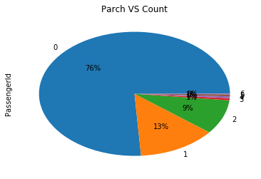

```python
sort_Parch = titanic_df.groupby('Parch').count()['PassengerId']
print sort_Parch
titanic_df.groupby('Parch')['PassengerId'].count().plot(kind = 'pie',autopct = '%.0f%%')
plt.title('Parch VS Count')
plt.show()
```

```
Parch
0    0.343658
1    0.550847
2    0.500000
3    0.600000
4    0.000000
5    0.200000
6    0.000000
Name: Survived, dtype: float64
```

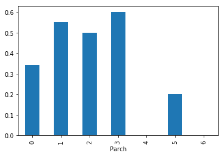

```python
Parch_survived = titanic_df.groupby('Parch').mean()['Survived']
print Parch_survived
Parch_survived.plot.bar()
```

### 综合以上分析可以得出结论

根据对数据的一些分析得到的结果基本和猜测的一致，女性生存率比男性的3倍还要多，对舱位的大体分析可以看出头等舱二等舱的生存率是比较高的，这也客观的反映了当时对富人阶级的优待，可猜测在头等舱和二等舱放的救生艇会更多，关于年龄，只能明确得出0～10岁的生存率最高，老年人最低，符合常理。

#### 局限性

- 可能会存在数据的缺失，也就是说这个样本数据不能代表整体数据，例如有的时候会存在一票多用的情况，这个时候计算结果会有偏差。
- 在分析年龄这一列的时候，使用的是前面的一个数填充缺失值，并不能代表真是数据，因此对年龄和生存率的分析也会存在一些偏差。
- 在分析单变量与生存率的关系的时候，可能会有其他不确定性因素的影响。
- 参考文献：
- 泰坦尼克号的详细参考文献
- pandas的可视化函数
- Python 数据可视化入门
- 数据缺失值的处理